# Homework1

Ramazan Yarar

10/18/2018

## Homework 1

# Data Preparation

- Data Import

```r
library (mltools)
library (data.table)
library (devtools)
library(easyGgplot2)
dt_odds<- readRDS("~/Documents/Dersler/Fall-2018/IE-582/df9b1196-e3cf-4cc7-9159-f236fe738215_odd_details.rds")
dt_matches <- readRDS("~/Documents/Dersler/Fall-2018/IE-582/df9b1196-e3cf-4cc7-9159-f236fe738215_matches.rds")
```

- Data manipulation steps for odds table

```r
# filtering data for project scope
dt_odds_filtered <- dt_odds[betType=="ou" & totalhandicap==2.5]

# ?? rank data to analysis first and last odds
dt_odds_filtered[,rnkl:=rank(date,ties.method= "max"), by = list(matchId,oddtype,bookmaker)]
dt_odds_filtered[,rnkf:=1:.N, by = list(matchId,oddtype,bookmaker)]

dt_odds_rnkf <- dt_odds_filtered[rnkf==1] # for first odds
dt_odds_rnkl <- dt_odds_filtered[rnkl==1] # for last odds
dt_odds_rnkf<- dt_odds_rnkf[,.(matchId,bookmaker,oddtype,date,odd)]
dt_odds_rnkl<- dt_odds_rnkl[,.(matchId,bookmaker,oddtype,date,odd)]

# I pivot table to combine two odds in one row for each match

dt_odds_pvtf <- dcast(dt_odds_rnkf,matchId+bookmaker ~ oddtype)
dt_odds_pvtl <- dcast(dt_odds_rnkl,matchId+bookmaker ~ oddtype)

# I calculate probability for odds
dt_odds_pvtf$overprobability <- as.numeric((1/dt_odds_pvtf$over)*(1/((1/dt_odds_pvtf$over)+(1/dt_odds_pvtf$under))))

dt_odds_pvtl$overprobability <- as.numeric((1/dt_odds_pvtl$over)*(1/((1/dt_odds_pvtl$over)+(1/dt_odds_pvtl$under))))

dt_odds_pvtf$underprobability <- as.numeric((1/dt_odds_pvtf$under)*(1/((1/dt_odds_pvtf$over)+(1/dt_odds_pvtf$under))))

dt_odds_pvtl$underprobability <- as.numeric((1/dt_odds_pvtl$under)*(1/((1/dt_odds_pvtl$over)+(1/dt_odds_pvtl$under))))
```

- Data manipulation steps for matches table

```r
# I split score to calculate whether result is over or under
dt_matches[,c("score1","score2"):= tstrsplit(score,":",fixed=TRUE)]
dt_matches <- dt_matches[,score1:=as.integer(score1)] # to be ensure for calculation
dt_matches <- dt_matches[,score2:=as.integer(score2)]
# I convert date formats
dt_matches <- dt_matches[,date:=as.Date(as.POSIXct(date,origin="1970-01-01",tz = "UTC",tryformats="%Y/%m/%d"))]
# I added year columns and flag column for whether matches score totals is over 2.5
dt_matches$year<-dt_matches[,format(date,"%Y")]
dt_matches$totalgoal <- dt_matches$score1 + dt_matches$score2
dt_matches$IsOver <- as.integer(ifelse(dt_matches$totalgoal>2.5,1, 0))
```

# Joining tables

```r
# I create setkey to join tables
setkey(dt_matches,matchId)
setkey(dt_odds_pvtf,matchId)
setkey(dt_odds_pvtl,matchId)
# I joined tables
dt_mergedf <- merge(dt_odds_pvtf,unique(dt_matches),all.x=TRUE)
dt_mergedl <- merge(dt_odds_pvtl,unique(dt_matches),all.x=TRUE)

# I create bins to analysis and join with my odd and matches table

dt_bins_ds <- data.table(a=c(0,0.05,0.1,0.15,0.20,0.25,0.30,0.35,0.4,0.45,0.5,0.55,0.6,0.65,0.7,0.75,0.8,0.85,0.9,0.95),b=c(0.05,0.1,0.15,0.20,0.25,0.30,0.35,0.4,0.45,0.5,0.55,0.6,0.65,0.7,0.75,0.8,0.85,0.9,0.95,1)) # to bins scale

dt_bins<- bin_data(dt_mergedf,binCol ="overprobability",bins=dt_bins_ds,returnDT=TRUE,binType="explicit",boundaryType="(lorc")

dt_matches_finalf<-merge(dt_mergedf,unique(dt_bins),by.x="overprobability",by.y="BinVal",all.x  =TRUE) # remove duplicate

dt_matches_finall<-merge(dt_mergedl,unique(dt_bins),by.x="overprobability",by.y="BinVal",all.x  =TRUE)

dt_matches_summaryf<-dt_matches_finalf[,.(sum(IsOver,na.rm=TRUE)/.N,mean(overprobability)), by=Bin]

dt_matches_summaryl<-dt_matches_finall[,.(sum(IsOver,na.rm=TRUE)/.N,mean(overprobability)), by=Bin]

# I plot example matrix
head(dt_matches_summaryl)
```

```
##            Bin        V1        V2
## 1:        <NA> 0.5074074 0.5163945
## 2: (0.3, 0.35] 0.2105263 0.3412751
## 3: (0.35, 0.4] 0.3578717 0.3878909
## 4: (0.4, 0.45] 0.3978143 0.4295685
## 5: (0.45, 0.5] 0.5108457 0.4785421
## 6: (0.5, 0.55] 0.5509245 0.5265172
```

# Task 1a

- 10Bet Over Odds Performance

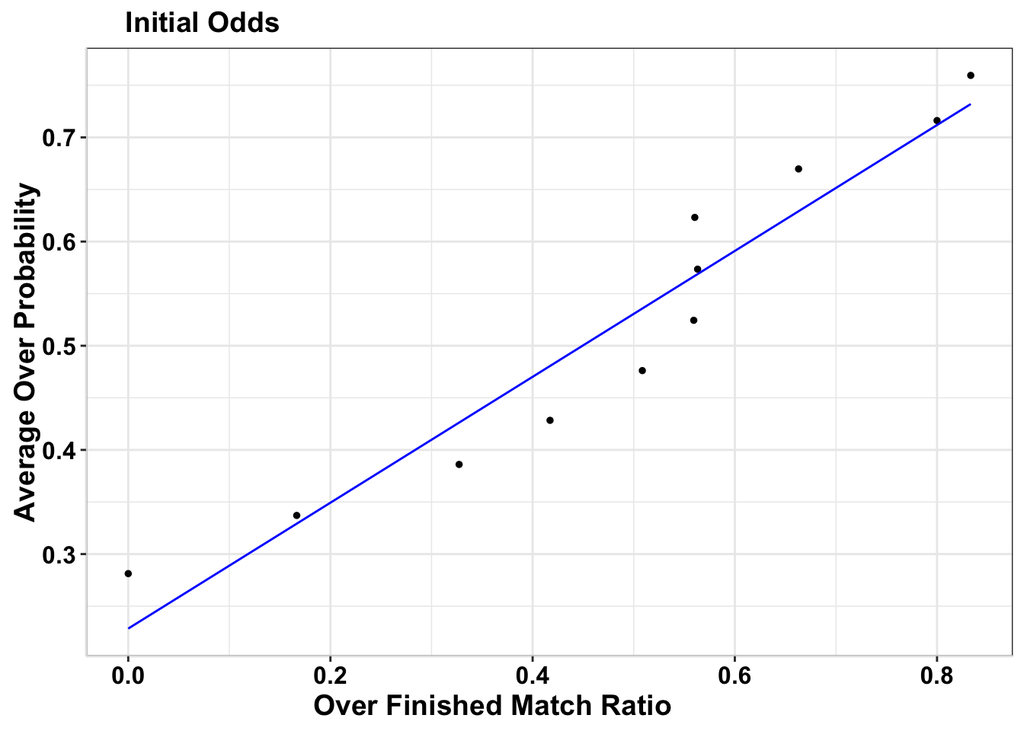

```r
# I filter bookmakers column with bet365 and plot


dt_final_10Betf<-dt_matches_finalf[bookmaker=="10Bet"]
dt_final_10Betl<-dt_matches_finall[bookmaker=="10Bet"]

dt_summary<-dt_final_10Betf[,.(sum(IsOver,na.rm=TRUE)/.N,mean(overprobability)), by=Bin]
ggplot2.scatterplot(dt_summary,
                    dt_summary$V1,
                    dt_summary$V2,
                    xtitle="Over Finished Match Ratio",
                    ytitle="Average Over Probability",
                    mainTitle="     Initial Odds",
                    addRegLine=TRUE,
                    regLineColor="blue",
                    backgroundColor="white")
```

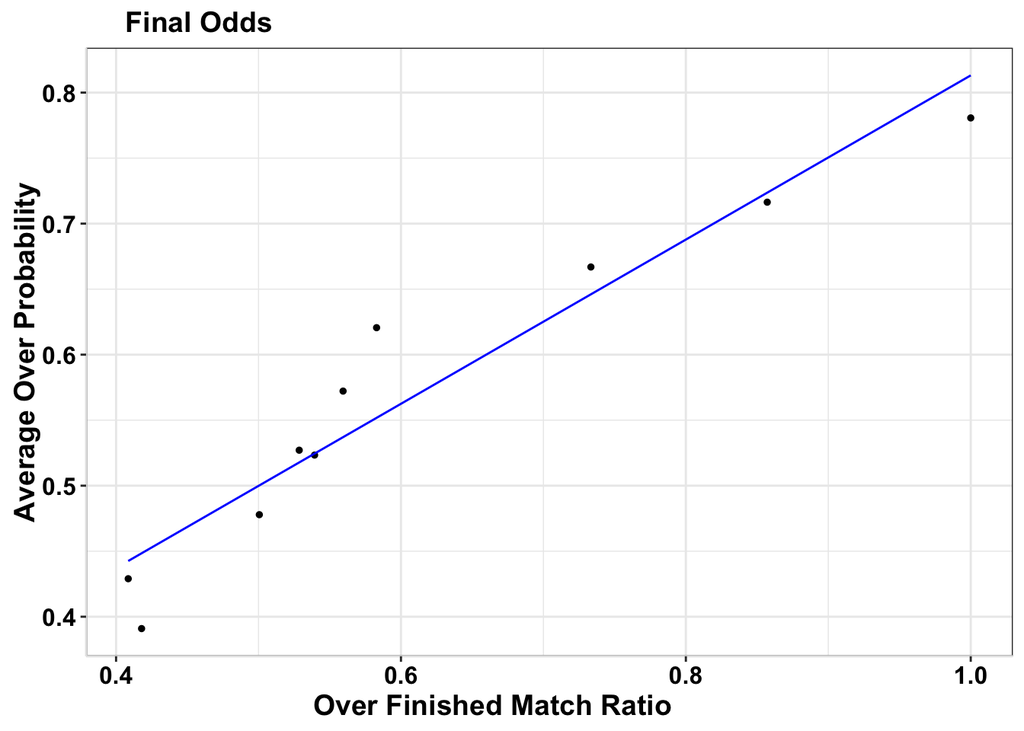

```r
dt_summary<-dt_final_10Betl[,.(sum(IsOver,na.rm=TRUE)/.N,mean(overprobability)), by=Bin]
ggplot2.scatterplot(dt_summary,
                    dt_summary$V1,
                    dt_summary$V2,
                    xtitle="Over Finished Match Ratio",
                    ytitle="Average Over Probability",
                    mainTitle="     Final Odds",
                    addRegLine=TRUE,
                    regLineColor="blue",
                    backgroundColor="white")
```

Probabilty generally convergence regression line in low probability. Also Final odds are closer than initial

- bet365’s Over Odds Performance

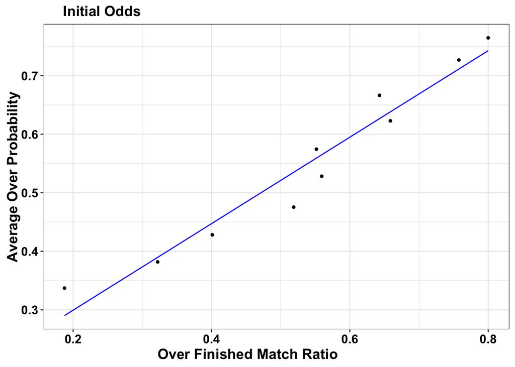

```r
# I filter bookmakers column with bet365 and plot

dt_final_bet365f<-dt_matches_finalf[bookmaker=="bet365"]
dt_final_bet365l<-dt_matches_finall[bookmaker=="bet365"]

dt_summary<-dt_final_bet365f[,.(sum(IsOver,na.rm=TRUE)/.N,mean(overprobability)), by=Bin]
ggplot2.scatterplot(dt_summary,
                    dt_summary$V1,
                    dt_summary$V2,
                    xtitle="Over Finished Match Ratio",
                    ytitle="Average Over Probability",
                    mainTitle="     Initial Odds",
                    addRegLine=TRUE,
                    regLineColor="blue",
                    backgroundColor="white")
```

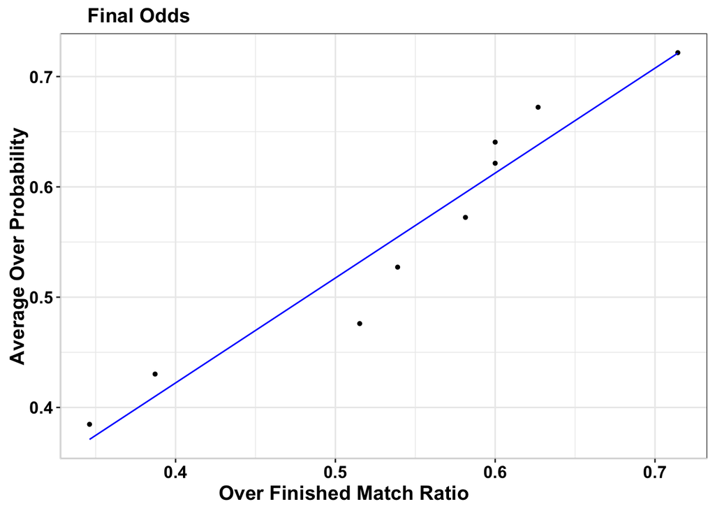

```r
dt_summary<-dt_final_bet365l[,.(sum(IsOver,na.rm=TRUE)/.N,mean(overprobability)), by=Bin]
ggplot2.scatterplot(dt_summary,
                    dt_summary$V1,
                    dt_summary$V2,
                    xtitle="Over Finished Match Ratio",
                    ytitle="Average Over Probability",
                    mainTitle="     Final Odds",
                    addRegLine=TRUE,
                    regLineColor="blue",
                    backgroundColor="white")
```

It has good correlation on high probability

- Betsafe’s Over Odds Performance

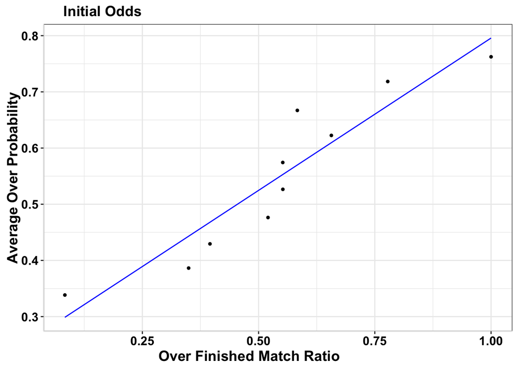

```r
# I filter bookmakers column with bet365 and plot

dt_final_Betsafef<-dt_matches_finalf[bookmaker=="Betsafe"]
dt_final_Betsafel<-dt_matches_finall[bookmaker=="Betsafe"]

dt_summary<-dt_final_Betsafef[,.(sum(IsOver,na.rm=TRUE)/.N,mean(overprobability)), by=Bin]
ggplot2.scatterplot(dt_summary,
                    dt_summary$V1,
                    dt_summary$V2,
                    xtitle="Over Finished Match Ratio",
                    ytitle="Average Over Probability",
                    mainTitle="     Initial Odds",
                    addRegLine=TRUE,
                    regLineColor="blue",
                    backgroundColor="white")
```

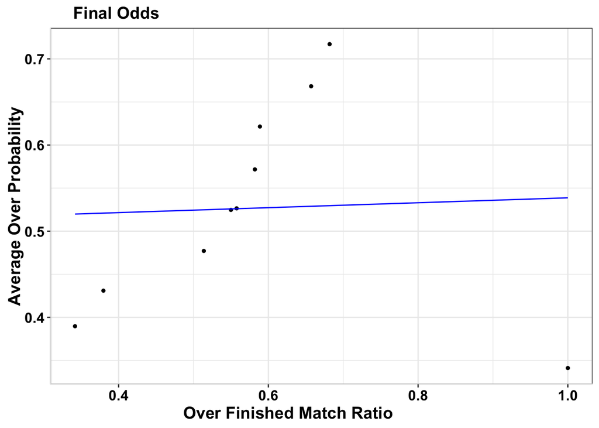

```r
dt_summary<-dt_final_Betsafel[,.(sum(IsOver,na.rm=TRUE)/.N,mean(overprobability)), by=Bin]
ggplot2.scatterplot(dt_summary,
                    dt_summary$V1,
                    dt_summary$V2,
                    xtitle="Over Finished Match Ratio",
                    ytitle="Average Over Probability",
                    mainTitle="     Final Odds",
                    addRegLine=TRUE,
                    regLineColor="blue",
                    backgroundColor="white")
```

- bwin’s Over Odds Performance

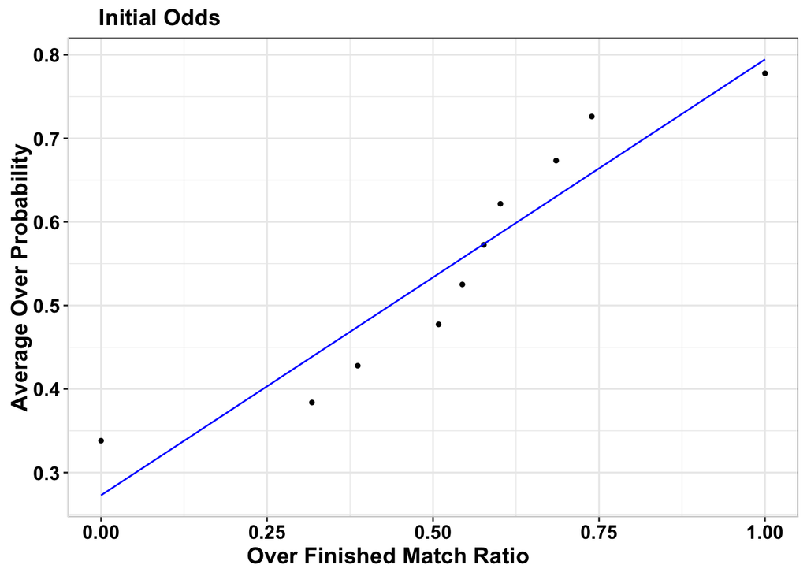

```r
# I filter bookmakers column with bet365 and plot

dt_final_bwinf<-dt_matches_finalf[bookmaker=="bwin"]
dt_final_bwinl<-dt_matches_finall[bookmaker=="bwin"]

dt_summary<-dt_final_bwinf[,.(sum(IsOver,na.rm=TRUE)/.N,mean(overprobability)), by=Bin]
ggplot2.scatterplot(dt_summary,
                    dt_summary$V1,
                    dt_summary$V2,
                    xtitle="Over Finished Match Ratio",
                    ytitle="Average Over Probability",
                    mainTitle="     Initial Odds",
                    addRegLine=TRUE,
                    regLineColor="blue",
                    backgroundColor="white")
```

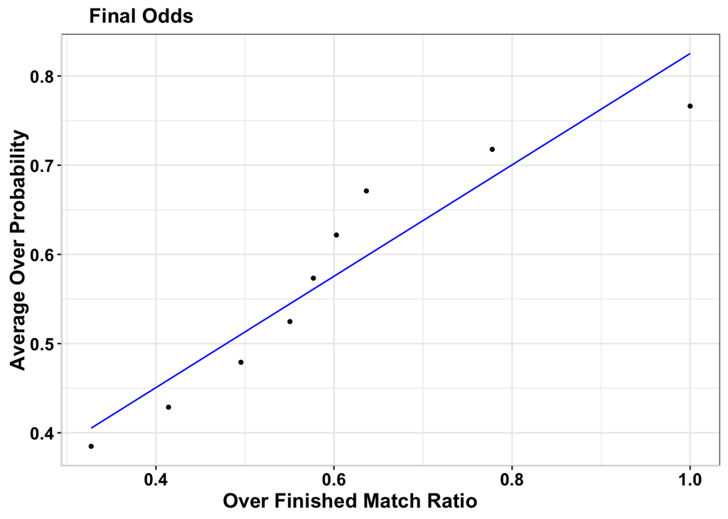

```r
dt_summary<-dt_final_bwinl[,.(sum(IsOver,na.rm=TRUE)/.N,mean(overprobability)), by=Bin]
ggplot2.scatterplot(dt_summary,
                    dt_summary$V1,
                    dt_summary$V2,
                    xtitle="Over Finished Match Ratio",
                    ytitle="Average Over Probability",
                    mainTitle="     Final Odds",
                    addRegLine=TRUE,
                    regLineColor="blue",
                    backgroundColor="white")
```

- bet-at-home’s Over Odds Performance

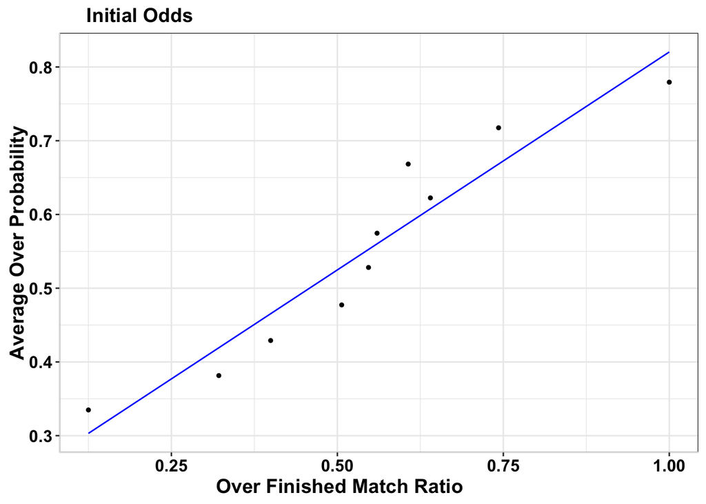

```r
# I filter bookmakers column with bet365 and plot

dt_final_betf<-dt_matches_finalf[bookmaker=="bet-at-home"]
dt_final_betl<-dt_matches_finall[bookmaker=="bet-at-home"]

dt_summary<-dt_final_betf[,.(sum(IsOver,na.rm=TRUE)/.N,mean(overprobability)), by=Bin]
ggplot2.scatterplot(dt_summary,
                    dt_summary$V1,
                    dt_summary$V2,
                    xtitle="Over Finished Match Ratio",
                    ytitle="Average Over Probability",
                    mainTitle="     Initial Odds",
                    addRegLine=TRUE,
                    regLineColor="blue",
                    backgroundColor="white")
```

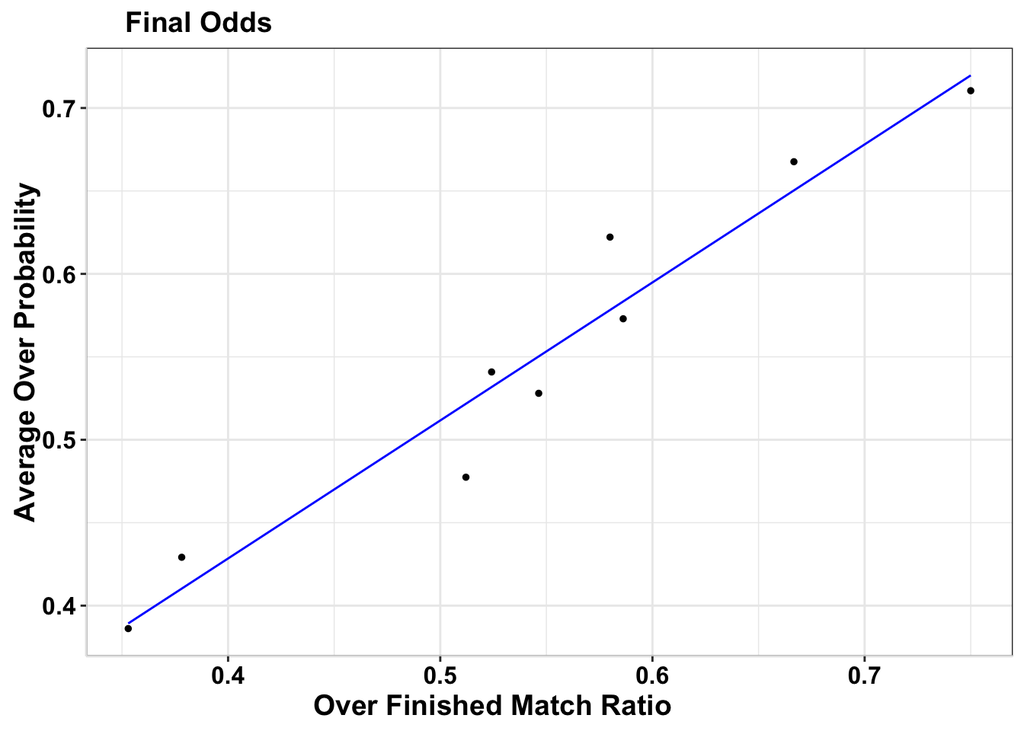

```r
dt_summary<-dt_final_betl[,.(sum(IsOver,na.rm=TRUE)/.N,mean(overprobability)), by=Bin]
ggplot2.scatterplot(dt_summary,
                    dt_summary$V1,
                    dt_summary$V2,
                    xtitle="Over Finished Match Ratio",
                    ytitle="Average Over Probability",
                    mainTitle="     Final Odds",
                    addRegLine=TRUE,
                    regLineColor="blue",
                    backgroundColor="white")
```

## Task1b

- I selected bet-at-home

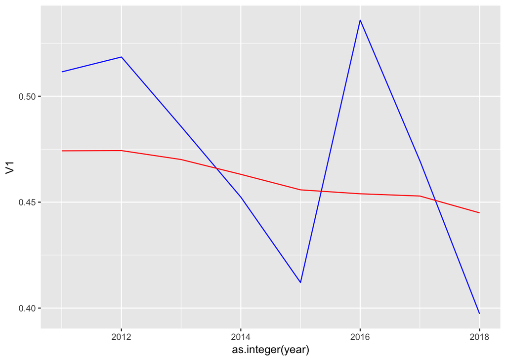

```r
# I filter data and group by with year
dt_final_bet<-dt_matches_finalf[bookmaker=="bet-at-home" & Bin %in% c("(0.4, 0.45]","(0.45, 0.5]")]
dt_summary_bet<-na.omit(dt_final_bet[,.(sum(IsOver,na.rm=TRUE)/.N,mean(overprobability)), by=.(year)])

# plot
ggplot() +
  geom_line(data = dt_summary_bet, aes(x = as.integer(year), y = V1), color = "blue") +
  geom_line(data = dt_summary_bet, aes(x = as.integer(year), y = V2), color = "red")
```

- Blue line is over percentage of matches , red line is over probability of odds

## Task 2

I considered on changing of favourite odds. For example , bookmakers initially give low odds for soccer team which play in home than change odds and give low odds for away teams.I detected changing favorite odds for 188BET. Also, I find ratio of matches resulting same with final favorite odds over these matches. I plot it yearly

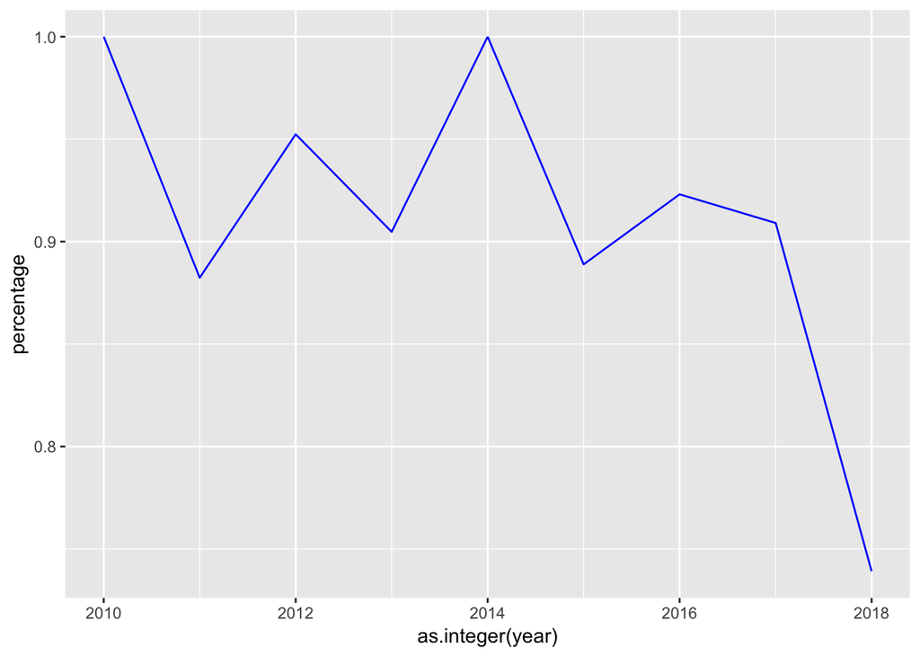

```r
# I filter betType and bookmaker columns
dt_odds_tsk2 <- dt_odds[betType=="1x2" & bookmaker=="188BET"]

# I give rank matches in comparison by odds and date to detect favourite odds changing

dt_odds_tsk2f<-dt_odds_tsk2[,rnk:=rank(date,ties.method= "min"),
                            by = list(matchId,oddtype)][rnk==1] # first odds

dt_odds_tsk2f_fvt<-dt_odds_tsk2f[,fvtrnk:=rank(odd,ties.method= "min"),
                                 by = list(matchId)][fvtrnk==1] # first favourite odds

dt_odds_tsk2l<-dt_odds_tsk2[,rnkl:=rank(-date,ties.method= "max"),
                            by = list(matchId,oddtype,bookmaker)][rnkl==1] # final odds

dt_odds_tsk2l_fvt<-dt_odds_tsk2l[,fvtrnk:=rank(odd,ties.method= "min"),
                                 by = list(matchId)][fvtrnk==1]  # final favourite odds

# I merged final and first odds
dt_odds_tsk2all<-funion(dt_odds_tsk2l_fvt[,.(matchId,oddtype,date,odd)]
                        ,dt_odds_tsk2f_fvt[,.(matchId,oddtype,date,odd)]
                        ,all=TRUE)

# I pivoted table  in comparison to oddtype for
dt_odds_tsk2_pvt <- dcast(dt_odds_tsk2all,matchId ~ oddtype)
# Changed matches.Because there is no oddX bets, only odd1 and odd2
dt_odds_fvtchanged<-dt_odds_tsk2_pvt[odd1==1 | odd2==1]


# I create dummy result bettype columns to find what bet type should have been

dt_matches$resultbet<-ifelse(dt_matches$score1>dt_matches$score2, "odd1",ifelse(dt_matches$score1<dt_matches$score2,"odd2", "oddX"))

# I merge matches table with changed matches to filter all matches
dt_match_result<-merge(dt_odds_fvtchanged,dt_matches,x.all=TRUE)

dt_tsk2_final<-merge(dt_match_result,unique(dt_odds_tsk2l_fvt),x.all=TRUE)

# I create dummy IsCorrect columns to see correct prediction

dt_tsk2_final[,IsCorrect:=ifelse(dt_tsk2_final$oddtype==dt_tsk2_final$resultbet,1,0),
                                 by = list(matchId)]

# I find succes percentage of changed favourite odds
dt_tsk2_summary<-dt_tsk2_final[,percentage:=.(sum(IsCorrect,na.rm=TRUE)/.N), by=.(year)]


# Plot
ggplot() +
  geom_line(data = dt_tsk2_summary, aes(x = as.integer(year), y = percentage), color = "blue")
```